# Population Simulation

# Initial Values

These are the parameters to construct our copula with tail dependence for which we obtain our environmental noise.

- **n:** 10^{4}
- **dim:** 150
- **rho:** 0.1
- **thresh_hi:** 0.6
- **thresh_lo:** 0

These are the values that we have when we simulate our population throughout time.

- **r:** 1
- **numSimulations:** 1
- **initPopSize:** 500
- **carryingCapacity:** 500
- **timeSteps:** 10^{4}

This is if we set a seed for our program.

- **setseed:** FALSE
- **seed:** 10

This is where we obtain additional information we want to include in our document.

- **filename:** testtext
- **fileext:** .txt

# Construction of a Tail Dependent Random Variable

Here we construct our copula with tail dependence with the newCopulaWithTailDependence function.

```r
res<-newCopulaWithTailDependece(params$n,params$dim,params$rho,params$thresh_lo,params$thresh_hi)
```

The parameters that we pass into the function indicate that:

- we sample from 10^{4} points from a copula
- our copula has dimension 150
- we use the value of 0.1 for rho where rho is the normal copula parameter for the region of the copula that is not tail dependent.
- we have the values of 0 for thresh_lo and 0.6 for thresh_hi.

This means that our copula has right tail dependence in every dimension.

# Transformation of our Random Variable and Construction of New Random Variables

We now transforms all of our marginals of our 150-dimensional copula with right tail dependence into normal marginals.

```r
res<-qnorm(res)
```

We now calculate the covariance matrix for 150-variate normal random variable.

```r
covMatrix <- matrix(data=rep(0,times=params$dim*params$dim),nrow=params$dim,byrow=TRUE)
for(i in 1:params$dim){
  for(j in 1:(params$dim)){
   covMatrix[i,j] <- cov(res[,i],res[,j])
  }
}
```

We sum all of the entries of our covariance matrix to obtain the variance of the sum of all random variable to have

```r
varSumRetain <- sum(covMatrix)
```

We use this variance to find the rho parameter to construct a 150-variate normal copula that has the same value for the variance of the sum of the marginals as our tail dependent random variable

```r
rho <- findNormalCopulaParam(params$dim, varSumRetain)
newNormalCop <- normalCopula(param = rho,dim =params$dim)
newNormCop <- rCopula(params$n, newNormalCop)
```

We new transform this normal copula into normal marginals.

```r
newMultiNormMarg <- qnorm(newNormCop)
```

We now create our comonotonic random variable with dimension 150

```r
com_mat <- matrix(data=replicate(n=params$dim,res[,1]),ncol=params$dim)
```

This is the empirical cumulative density function of three random variables. These three random variables are the sum of the 150 marginals of each the three cases. The variance of the sum of these random variables respectively are:

- **comonotonic:** 2.25041910^{4}
- **comonotonic** in the tail: 1.736197710^{4}
- **not comonotonic:** 1.717694710^{4}

Note that the variance for the comonotonic in the tail case and not comonotonic are similar. Also note that the variance for the comonotonic case is greater than the other two cases.

This is the ecdfplot of the sum of the marginals of each of the three random variables.

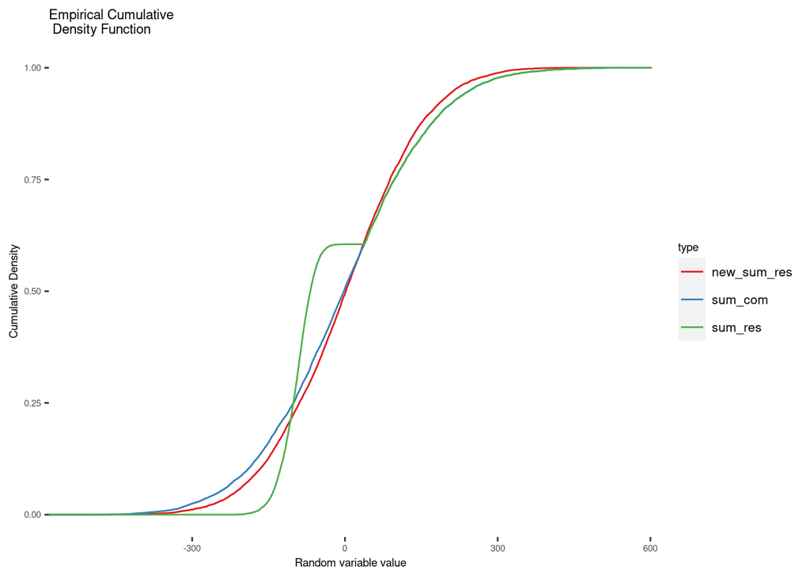

We have three random variables where each of them have 150 marginals. Each of these random variables represents the environmental noise on a population each with 150 metapopulations. We use a stochastic ricker model to model how the population fluctuates over time

```r
ricker <-function(curpop,r,k,eps){
  return(curpop*exp(r*(1-(curpop/k))+eps))
}
```

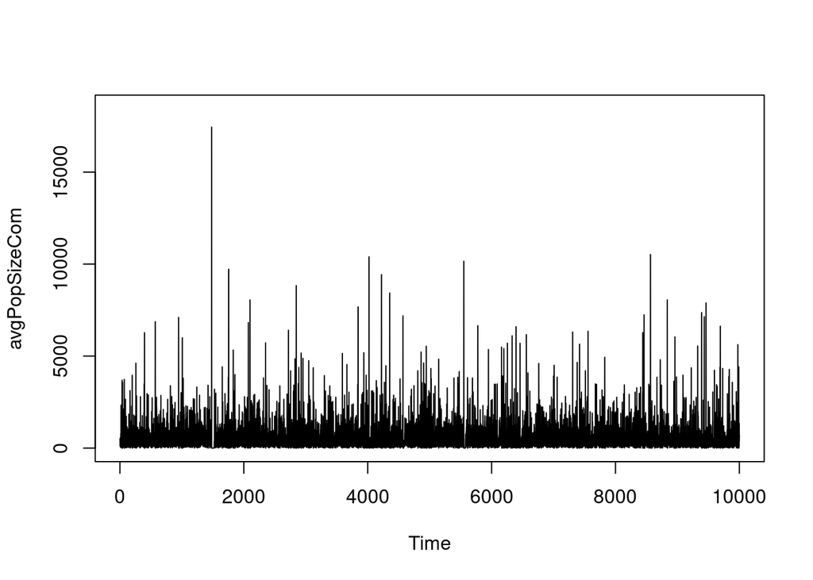

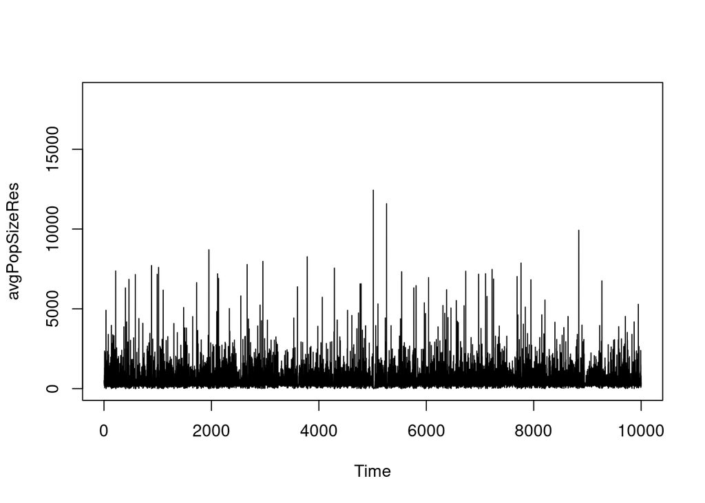

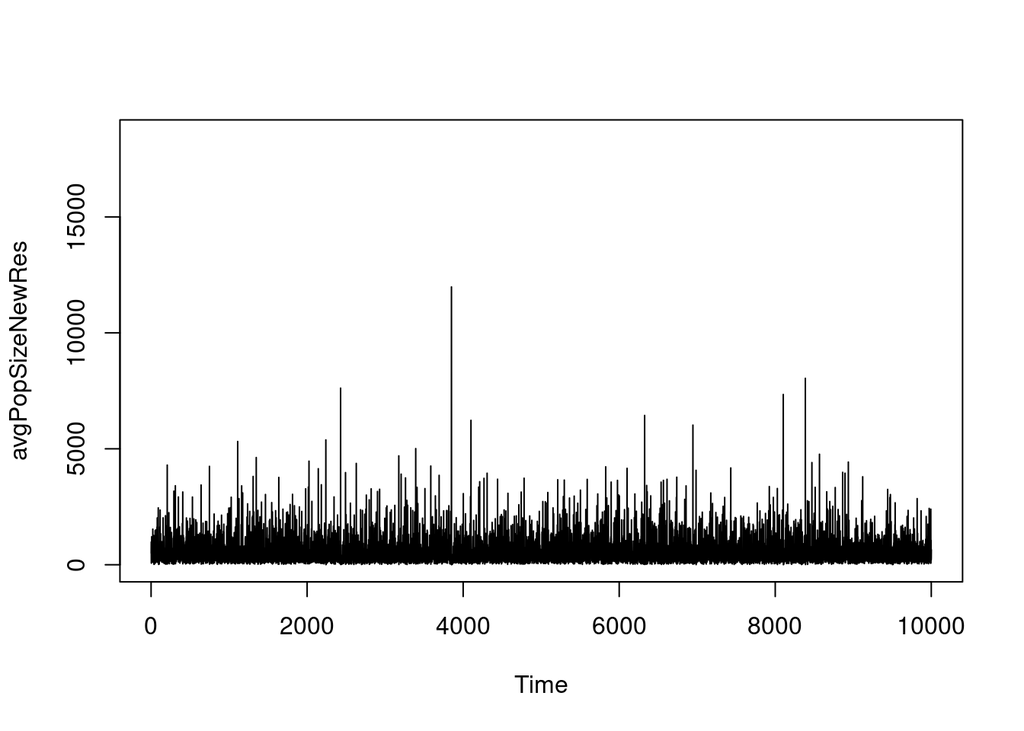

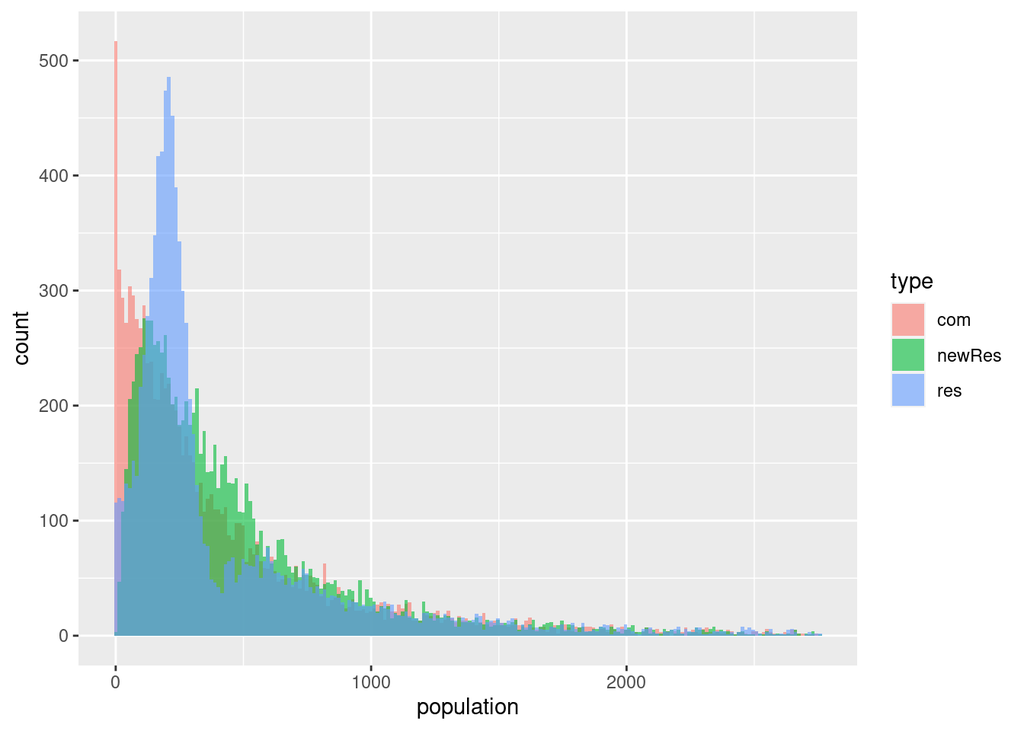

```r
upB <- max(quantile(avgPopSizeCom,0.98),quantile(avgPopSizeRes,0.98),quantile(avgPopSizeNewRes,0.98))

com <- data.frame(population =avgPopSizeCom[avgPopSizeCom<upB] )
res <- data.frame(population =avgPopSizeRes[avgPopSizeRes<upB] )
newRes <- data.frame(population =avgPopSizeNewRes[avgPopSizeNewRes<upB] )
com$type <- "com"
res$type <- "res"
newRes$type <- "newRes"

popfreq <- rbind(com,res,newRes)

ggplot(popfreq,aes(population,fill=type)) + geom_histogram(bins=200, alpha =0.6, position ='identity')
```

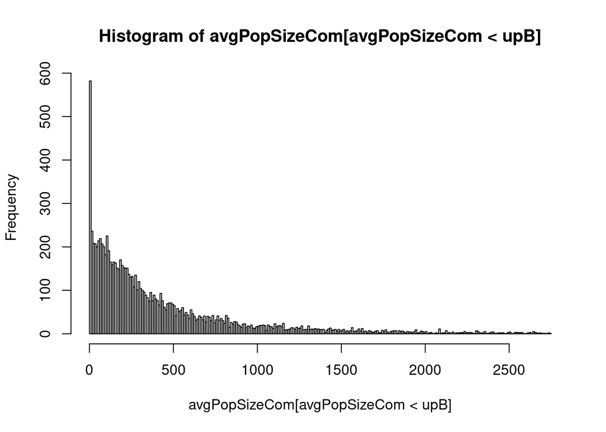

```r
hist(avgPopSizeCom[avgPopSizeCom<upB],breaks=200)
```

```r
print(paste0("mean: ", mean(avgPopSizeCom)," median: ", median(avgPopSizeCom)))
```

```
## [1] "mean: 496.543761883239 median: 259.725866554971"
```

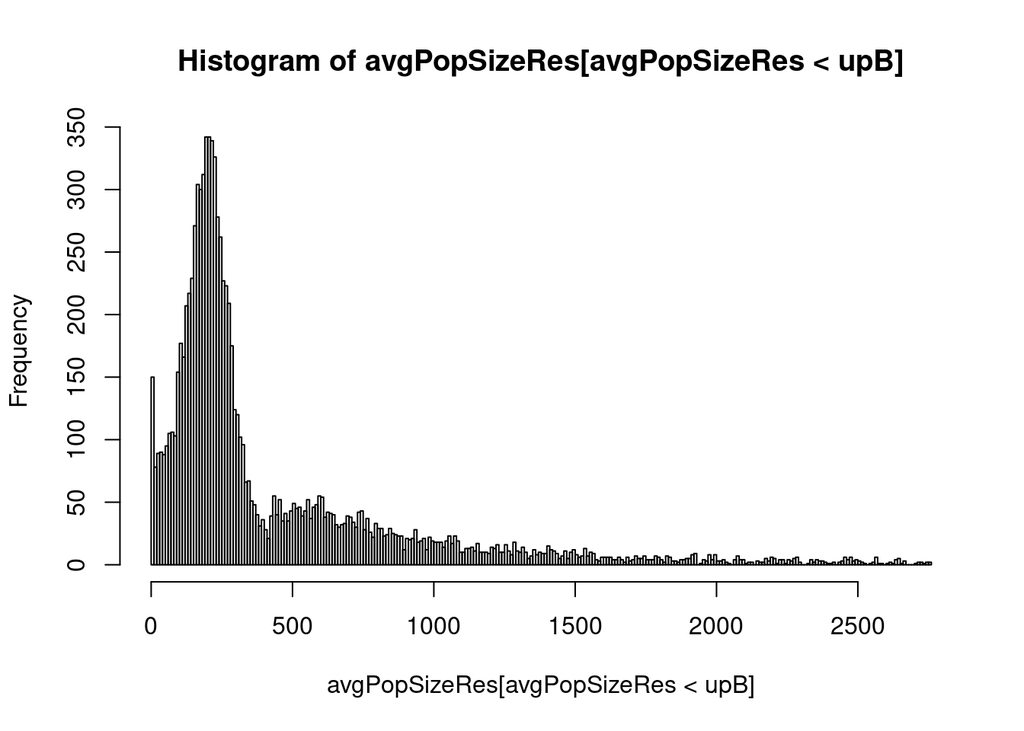

```r
hist(avgPopSizeRes[avgPopSizeRes<upB],breaks=200)
```

```r
print(paste0("mean: ", mean(avgPopSizeRes)," median: ", median(avgPopSizeRes)))
```

```
## [1] "mean: 505.799941460822 median: 245.131081181234"
```

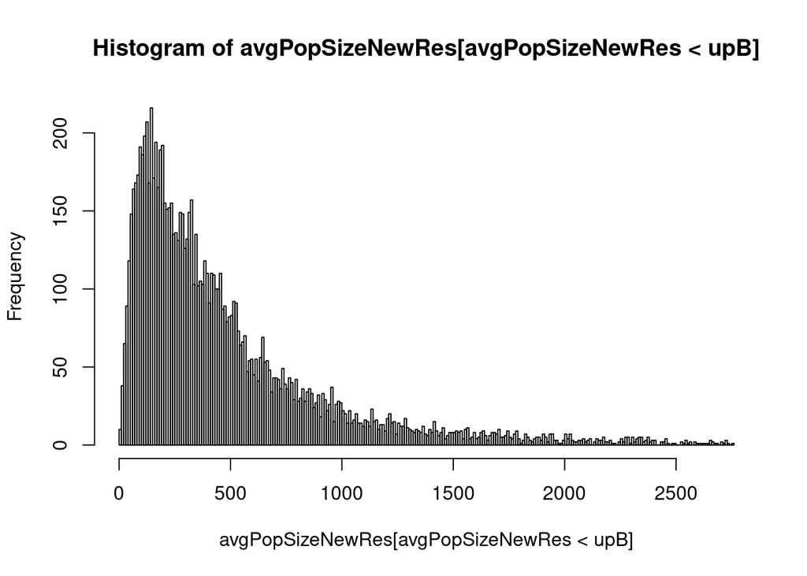

```r
hist(avgPopSizeNewRes[avgPopSizeNewRes<upB],breaks=200)
```

```r
print(paste0("mean: ", mean(avgPopSizeNewRes)," median: ", median(avgPopSizeNewRes)))
```

```
## [1] "mean: 510.621236333453 median: 337.871841497563"
```